# Alcohol Consumption

## Data Preperation

### Load Data

```python
import os
import pandas as pd

path1 = 'archive/student-mat.csv'
path2 = 'archive/student-por.csv'
def load_data(path1=path1, path2=path2):
    dataframes = [pd.read_csv(path1), pd.read_csv(path1)]
    return pd.concat(dataframes)
```

```python
students = load_data()
```

### Quick Look at Dataset

Looking at histograms, format of attributes, among other things. Added Talc for total consumtion through the week by adding Dalc and Walc. I then dropped Dalc and Walc.

```python
students.head()
```

|  | school | sex | age | address | famsize | Pstatus | Medu | Fedu | Mjob | Fjob | ... | famrel | freetime | goout | Dalc | Walc | health | absences | G1 | G2 | G3 |
| --- | --- | --- | --- | --- | --- | --- | --- | --- | --- | --- | --- | --- | --- | --- | --- | --- | --- | --- | --- | --- | --- |
| 0 | GP | F | 18 | U | GT3 | A | 4 | 4 | at_home | teacher | ... | 4 | 3 | 4 | 1 | 1 | 3 | 6 | 5 | 6 | 6 |
| 1 | GP | F | 17 | U | GT3 | T | 1 | 1 | at_home | other | ... | 5 | 3 | 3 | 1 | 1 | 3 | 4 | 5 | 5 | 6 |
| 2 | GP | F | 15 | U | LE3 | T | 1 | 1 | at_home | other | ... | 4 | 3 | 2 | 2 | 3 | 3 | 10 | 7 | 8 | 10 |
| 3 | GP | F | 15 | U | GT3 | T | 4 | 2 | health | services | ... | 3 | 2 | 2 | 1 | 1 | 5 | 2 | 15 | 14 | 15 |
| 4 | GP | F | 16 | U | GT3 | T | 3 | 3 | other | other | ... | 4 | 3 | 2 | 1 | 2 | 5 | 4 | 6 | 10 | 10 |

5 rows × 33 columns

```python
students.info()
```

```
<class 'pandas.core.frame.DataFrame'>
Int64Index: 790 entries, 0 to 394
Data columns (total 33 columns):
 #   Column      Non-Null Count  Dtype
---  ------      --------------  -----
 0   school      790 non-null    object
 1   sex         790 non-null    object
 2   age         790 non-null    int64
 3   address     790 non-null    object
 4   famsize     790 non-null    object
 5   Pstatus     790 non-null    object
 6   Medu        790 non-null    int64
 7   Fedu        790 non-null    int64
 8   Mjob        790 non-null    object
 9   Fjob        790 non-null    object
```

[output cut: 25 more lines]

```python
students.describe()
```

|  | age | Medu | Fedu | traveltime | studytime | failures | famrel | freetime | goout | Dalc | Walc | health | absences | G1 | G2 | G3 |
| --- | --- | --- | --- | --- | --- | --- | --- | --- | --- | --- | --- | --- | --- | --- | --- | --- |
| count | 790.000000 | 790.000000 | 790.000000 | 790.000000 | 790.000000 | 790.000000 | 790.000000 | 790.000000 | 790.000000 | 790.000000 | 790.000000 | 790.000000 | 790.000000 | 790.000000 | 790.000000 | 790.000000 |
| mean | 16.696203 | 2.749367 | 2.521519 | 1.448101 | 2.035443 | 0.334177 | 3.944304 | 3.235443 | 3.108861 | 1.481013 | 2.291139 | 3.554430 | 5.708861 | 10.908861 | 10.713924 | 10.415190 |
| std | 1.275234 | 1.094041 | 1.087511 | 0.697063 | 0.838708 | 0.743180 | 0.896090 | 0.998229 | 1.112572 | 0.890177 | 1.287080 | 1.389422 | 7.998022 | 3.317091 | 3.759120 | 4.578538 |
| min | 15.000000 | 0.000000 | 0.000000 | 1.000000 | 1.000000 | 0.000000 | 1.000000 | 1.000000 | 1.000000 | 1.000000 | 1.000000 | 1.000000 | 0.000000 | 3.000000 | 0.000000 | 0.000000 |
| 25% | 16.000000 | 2.000000 | 2.000000 | 1.000000 | 1.000000 | 0.000000 | 4.000000 | 3.000000 | 2.000000 | 1.000000 | 1.000000 | 3.000000 | 0.000000 | 8.000000 | 9.000000 | 8.000000 |
| 50% | 17.000000 | 3.000000 | 2.000000 | 1.000000 | 2.000000 | 0.000000 | 4.000000 | 3.000000 | 3.000000 | 1.000000 | 2.000000 | 4.000000 | 4.000000 | 11.000000 | 11.000000 | 11.000000 |
| 75% | 18.000000 | 4.000000 | 3.000000 | 2.000000 | 2.000000 | 0.000000 | 5.000000 | 4.000000 | 4.000000 | 2.000000 | 3.000000 | 5.000000 | 8.000000 | 13.000000 | 13.000000 | 14.000000 |
| max | 22.000000 | 4.000000 | 4.000000 | 4.000000 | 4.000000 | 3.000000 | 5.000000 | 5.000000 | 5.000000 | 5.000000 | 5.000000 | 5.000000 | 75.000000 | 19.000000 | 19.000000 | 20.000000 |

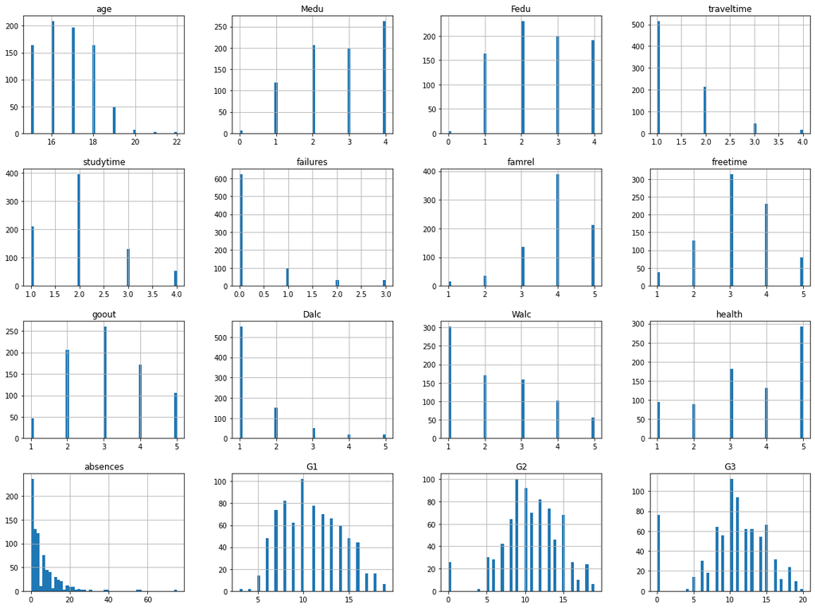

```python
%matplotlib inline
import matplotlib.pyplot as plt
students.hist(bins=50, figsize=(20,15))
plt.show()
```

```python
students['Talc'] = students['Dalc'] + students['Walc']
students = students.drop(columns=['Dalc', 'Walc'])
```

### Create Test Set

I used a stratified shuffle split using the 'goout' attribute as it had the strongest correlation to the 'Talc' attribute

```python
corr_matrix = students.corr()
corr_matrix['Talc'].sort_values(ascending=False)
```

```
Talc          1.000000
goout         0.392683
freetime      0.189754
failures      0.153203
traveltime    0.149134
absences      0.138687
age           0.134972
health        0.094662
Fedu         -0.007127
Medu         -0.021681
G3           -0.058245
G2           -0.083901
famrel       -0.108427
G1           -0.124158
studytime    -0.252698
Name: Talc, dtype: float64
```

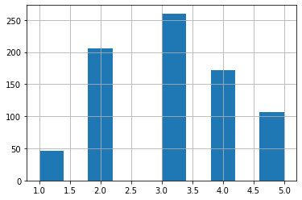

```python
students['goout'].hist()
```

```python
from sklearn.model_selection import StratifiedShuffleSplit

split = StratifiedShuffleSplit(n_splits=1, test_size=0.2, random_state=42)
for train_index, test_index in split.split(students, students['goout']):
    strat_train_set = students.iloc[train_index]
    strat_test_set = students.iloc[test_index]
```

```python
strat_test_set['goout'].value_counts()/len(strat_test_set)
```

```
3    0.329114
2    0.259494
4    0.221519
5    0.132911
1    0.056962
Name: goout, dtype: float64
```

```python
students['goout'].value_counts()/len(students)
```

```
3    0.329114
2    0.260759
4    0.217722
5    0.134177
1    0.058228
Name: goout, dtype: float64
```

### Gaining Insights on the Data

Talc (Total Alcohol Consumtion) was most correlated with the attributes 'goout' and 'studytime'.

```python
students = strat_train_set.copy()
```

```python
corr_matrix = students.corr()
corr_matrix['Talc'].sort_values(ascending=False)
```

```
Talc          1.000000
goout         0.372098
freetime      0.177675
traveltime    0.165437
absences      0.149713
failures      0.140723
health        0.129867
age           0.119320
Fedu         -0.003216
Medu         -0.011320
G3           -0.059093
G2           -0.083255
G1           -0.123448
famrel       -0.143482
studytime    -0.264073
Name: Talc, dtype: float64
```

```
array([[<AxesSubplot:xlabel='Talc', ylabel='Talc'>,
        <AxesSubplot:xlabel='goout', ylabel='Talc'>,
        <AxesSubplot:xlabel='freetime', ylabel='Talc'>,
        <AxesSubplot:xlabel='failures', ylabel='Talc'>,
        <AxesSubplot:xlabel='studytime', ylabel='Talc'>,
        <AxesSubplot:xlabel='G1', ylabel='Talc'>],
       [<AxesSubplot:xlabel='Talc', ylabel='goout'>,
        <AxesSubplot:xlabel='goout', ylabel='goout'>,
        <AxesSubplot:xlabel='freetime', ylabel='goout'>,
        <AxesSubplot:xlabel='failures', ylabel='goout'>,
        <AxesSubplot:xlabel='studytime', ylabel='goout'>,
        <AxesSubplot:xlabel='G1', ylabel='goout'>],
       [<AxesSubplot:xlabel='Talc', ylabel='freetime'>,
        <AxesSubplot:xlabel='goout', ylabel='freetime'>,
        <AxesSubplot:xlabel='freetime', ylabel='freetime'>,
        <AxesSubplot:xlabel='failures', ylabel='freetime'>,
        <AxesSubplot:xlabel='studytime', ylabel='freetime'>,
        <AxesSubplot:xlabel='G1', ylabel='freetime'>],
       [<AxesSubplot:xlabel='Talc', ylabel='failures'>,
        <AxesSubplot:xlabel='goout', ylabel='failures'>,
        <AxesSubplot:xlabel='freetime', ylabel='failures'>,
        <AxesSubplot:xlabel='failures', ylabel='failures'>,
        <AxesSubplot:xlabel='studytime', ylabel='failures'>,
        <AxesSubplot:xlabel='G1', ylabel='failures'>],
       [<AxesSubplot:xlabel='Talc', ylabel='studytime'>,
        <AxesSubplot:xlabel='goout', ylabel='studytime'>,
        <AxesSubplot:xlabel='freetime', ylabel='studytime'>,
        <AxesSubplot:xlabel='failures', ylabel='studytime'>,
        <AxesSubplot:xlabel='studytime', ylabel='studytime'>,
        <AxesSubplot:xlabel='G1', ylabel='studytime'>],
       [<AxesSubplot:xlabel='Talc', ylabel='G1'>,
        <AxesSubplot:xlabel='goout', ylabel='G1'>,
        <AxesSubplot:xlabel='freetime', ylabel='G1'>,
        <AxesSubplot:xlabel='failures', ylabel='G1'>,
        <AxesSubplot:xlabel='studytime', ylabel='G1'>,
        <AxesSubplot:xlabel='G1', ylabel='G1'>]], dtype=object)
```

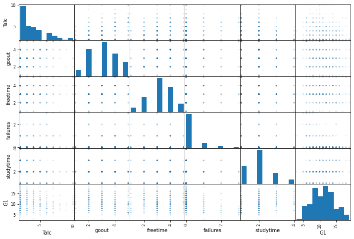

```python
from pandas.plotting import scatter_matrix

attributes = ['Talc', 'goout', 'freetime', 'failures', 'studytime', 'G1']
scatter_matrix(students[attributes], figsize=(12,8), alpha=0.05)
```

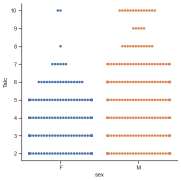

```python
import seaborn as sns
import matplotlib.pyplot as plt
sns.set_theme(style="ticks", color_codes=True)

sns.catplot(x="sex", y="Talc", kind="swarm", data=students)
```

### Experimenting with Attribute Combinations

I couldn't find any combinations that had a significant correlation to the Total Alcohol Consumtion, so I did not add any attributes.

```python
students['AvgGrade'] = (students['G1'] + students['G2'] + students['G3']) / 3
students['AvgPedu'] = (students['Fedu'] + students['Medu']) / 2
students['g/f'] = students['goout'] / students['freetime']
```

```python
corr_matrix = students.corr()
corr_matrix['Talc'].sort_values(ascending=False)
```

```
Talc          1.000000
goout         0.372098
freetime      0.177675
traveltime    0.165437
absences      0.149713
failures      0.140723
health        0.129867
age           0.119320
g/f           0.109831
Fedu         -0.003216
AvgPedu      -0.008157
Medu         -0.011320
G3           -0.059093
G2           -0.083255
AvgGrade     -0.089461
G1           -0.123448
famrel       -0.143482
studytime    -0.264073
Name: Talc, dtype: float64
```

```python
students = students.drop(columns=['AvgGrade', 'AvgPedu', 'g/f'])
```

### Data Cleaning

There are no missing values and no other cleaning is needed.

```python
students = strat_train_set.drop('Talc', axis=1)
students_labels = strat_train_set['Talc'].copy()
```

### Text and Categorical Attributes

I will be using the OneHotEncoder to encode the categories.

```python
num_attribs = ['goout', 'freetime', 'traveltime', 'absences', 'failures', 'health', 'age', 'Fedu', 'Medu',
              'G3', 'G2', 'G1', 'famrel', 'studytime']
students_num = students[num_attribs]
students_cat = students.drop(columns=num_attribs, axis=1)
```

```python
#dropping unnecessary attributes
for i in ['Fedu', 'Medu', 'failures']:
    num_attribs.remove(i)
students_num = students_num.drop(columns=['Fedu', 'Medu', 'failures'], axis=1)

students_cat = students_cat.drop(columns=['school'], axis=1)

students_num.head()
```

|  | goout | freetime | traveltime | absences | health | age | G3 | G2 | G1 | famrel | studytime |
| --- | --- | --- | --- | --- | --- | --- | --- | --- | --- | --- | --- |
| 363 | 4 | 3 | 1 | 0 | 1 | 17 | 15 | 15 | 16 | 2 | 2 |
| 229 | 3 | 2 | 2 | 10 | 3 | 17 | 12 | 10 | 12 | 3 | 3 |
| 228 | 2 | 3 | 4 | 14 | 3 | 18 | 9 | 8 | 10 | 4 | 2 |
| 27 | 4 | 2 | 1 | 4 | 1 | 15 | 15 | 16 | 15 | 2 | 1 |
| 322 | 2 | 3 | 1 | 3 | 3 | 17 | 11 | 11 | 11 | 3 | 3 |

```python
students_cat.head()
```

|  | sex | address | famsize | Pstatus | Mjob | Fjob | reason | guardian | schoolsup | famsup | paid | activities | nursery | higher | internet | romantic |
| --- | --- | --- | --- | --- | --- | --- | --- | --- | --- | --- | --- | --- | --- | --- | --- | --- |
| 363 | F | U | LE3 | T | at_home | at_home | course | mother | no | yes | yes | yes | yes | yes | yes | yes |
| 229 | F | U | GT3 | A | other | other | course | mother | no | no | no | yes | yes | yes | yes | yes |
| 228 | M | U | LE3 | T | at_home | other | course | mother | yes | yes | yes | yes | yes | yes | yes | yes |
| 27 | M | U | GT3 | T | health | services | other | mother | no | no | yes | no | yes | yes | yes | no |
| 322 | F | R | LE3 | T | services | services | course | mother | no | yes | yes | yes | yes | yes | yes | no |

```python
from sklearn.preprocessing import OneHotEncoder
encoder = OneHotEncoder()
students_cat_1hot = encoder.fit_transform(students_cat)
students_cat_1hot
```

```
<632x41 sparse matrix of type '<class 'numpy.float64'>'
	with 10112 stored elements in Compressed Sparse Row format>
```

### Creation of Pipelines

```python
from sklearn.pipeline import Pipeline
from sklearn.preprocessing import StandardScaler

num_pipeline = Pipeline([
    ('std_scaler', StandardScaler())
])

students_num_tr = num_pipeline.fit_transform(students_num)
```

```python
from sklearn.base import BaseEstimator, TransformerMixin

class DataFrameSelector(BaseEstimator, TransformerMixin):
    def __init__(self, attribute_names):
        self.attribute_names = attribute_names
    def fit(self, X, y=None):
        return self
    def transform(self, X):
        return X[self.attribute_names].values
```

```python
from sklearn.preprocessing import OneHotEncoder
cat_attribs = list(students_cat)

num_pipeline = Pipeline([
    ('selector', DataFrameSelector(num_attribs)),
    ('std_scaler', StandardScaler()),
])

cat_pipeline = Pipeline([
    ('selector', DataFrameSelector(cat_attribs)),
    ('one_hot_encoder', OneHotEncoder()),
])
```

```python
from sklearn.pipeline import FeatureUnion

full_pipeline = FeatureUnion([
    ('num_pipeline', num_pipeline),
    ('cat_pipeline', cat_pipeline),
])
```

```python
students_prepared = full_pipeline.fit_transform(students)
students_prepared
```

```
<632x52 sparse matrix of type '<class 'numpy.float64'>'
	with 17064 stored elements in Compressed Sparse Row format>
```

```python
students_prepared.shape
```

```
(632, 52)
```